# CAD-to-CAD retrieval: how far do cheap geometric descriptors get you?

Engineers rarely start a part from zero. They start from one that already exists, and the hard part is finding it: the useful precedent sits in an old project, under someone else's naming convention, and no filename search will surface it. Retrieval by *shape* is the obvious idea. This notebook asks what its cheapest honest version looks like — a global shape fingerprint over a 1008-part b-rep corpus, exact nearest-neighbour lookup, no learned model anywhere — and how you would know whether it works.

The second question turned out to be the harder one, and most of what follows is about it. Building the retriever was the quick part. Establishing that it retrieved anything *useful* cost me an evaluation method I had to demote after catching it rewarding the wrong thing, and ended in 277 hand-labelled judgements. Those labels carried the finding I did not go looking for: reuse is asymmetric, and a symmetric similarity score cannot express it.

Everything here is hand-built on purpose. I wanted to see where a transparent method breaks and why, so that an argument for a learned one could rest on evidence I had gathered myself.

## Dataset

A 1008-part subset of the [Fusion 360 Gallery Dataset](https://github.com/AutodeskAILab/Fusion360GalleryDataset) (segmentation set), published by Autodesk AI Lab. Each part is a single-body b-rep in STEP format with a per-face `.seg` label giving the modelling operation that created that face, over eight classes (`segment_names.json`): ExtrudeSide, ExtrudeEnd, CutSide, CutEnd, Fillet, Chamfer, RevolveSide, RevolveEnd.

The dataset is **not redistributed here**. `filelist.txt` names the 1008 stems and `DATASET.md` explains how to obtain them, place them at `fusion360subset/`, and what Autodesk's licence permits. Rendered images of these parts appear throughout this notebook as derived material under that licence — non-commercial research use only.

The subset is single-body parts, which is a real limitation and is revisited in the conclusion: a production archive of thin-walled, multi-body enclosures would stress a global fingerprint far harder than this corpus does.

*Origin: this work began as a take-home exercise. The problem framing, the relevance definition, the evaluation design and every conclusion below are my own. No company's material is reproduced here.*

## Solution

**Contents** — 0 Problem restatement · 1 Dataset (1.1 first look · 1.2 labels · 1.3 scalar block · 1.4 D2) · 2 Storage · 3 Retrieval (3.1 v0 · 3.2 sanity check) · 4 Evaluation (4.1 tests 1–2 · 4.2 seg referee · 4.3 confidence signal) · 5 v0 vs v1 · 6 Hardening pass · 7 Gold set · 8 Conclusion · References

### 0. Problem restatement, in my own words

We want to build a CAD-to-CAD retrieval system: it *accelerates* the design process because engineers can build on historical parts instead of starting from zero — **time to market is the currency.** So I break the problem into three layers:

1. **Definition**: understand what makes design B a useful retrieval for query A, *for an engineer*, understanding this definition of 'relevance'
2. **System**: use the STEP files' geometric semantics to operationalise and find similarity.
3. **Evaluation**: test the method honestly and see whether it actually works.

**Stated assumptions:**

1. The 1008-part STEP subset described above is the database.
2. "Relevant" is mine to define, with the definition and reasoning stated explicitly (below).
3. The single-body parts in this subset stand in for a real archive. Assemblies and multi-body parts are out of scope.
4. One fixed tessellation setting (deflection 0.1) is adequate for the whole database. The stability check tests that later.
5. A geometrically similar part is usually few edits from reusable. This is the core approximation, revisited throughout.

### 1. Dataset

Data extraction lives in `features.py` (annotated, one function per pipeline stage).

Dataflow: `part.stp` → OCC b-rep → {face-type fractions · exact volume/bbox · tessellated mesh → 2048 area-weighted samples → 64-bin D2 fingerprint} → one cached row per part.

The three arrays have strictly separated jobs (decision log rows 6, 8, 9): **`d2` ranks (used in v0)** ·

**`scalars` (used in v1)** (adopted only if it beats D2-alone in evaluation) ·

**`display` is shown beside every result and never ranks** — the system finds the shape family, the engineer judges size fit.

```python
from dataclasses import dataclass
import json
import pathlib

import numpy as np

import features  # our extraction module (same folder): all method parameters frozen there


@dataclass
class Dataset:
    stems: np.ndarray    # (N,)    part names
    d2: np.ndarray       # (N, 64) D2 fingerprints - the ONLY ranking signal in v0
    scalars: np.ndarray  # (N, 12) v1 candidate block (face-type mix etc.) - inert in v0
    display: np.ndarray  # (N, 5)  a, b, c, volume, bbox diagonal - shown to the user, never ranked
    meta: dict           # method parameters the cache was built with (deflection, bins, seed...)

    def index(self, stem: str) -> int:
        return int(np.where(self.stems == stem)[0][0])


CACHE = pathlib.Path("cache/features_v0.npz")


def load_dataset() -> Dataset:
    """Load the cached feature arrays; build the cache first if absent (~1 min for 1008 parts)."""
    if not CACHE.exists():
        features.main()
    z = np.load(CACHE, allow_pickle=True)
    return Dataset(z["stems"], z["d2"], z["scalars"], z["display"], json.loads(str(z["meta"])))


ds = load_dataset()
print(f"{len(ds.stems)} parts | d2 {ds.d2.shape} | scalars {ds.scalars.shape} | display {ds.display.shape}")
print("method fingerprint:", ds.meta)
```

```
1008 parts | d2 (1008, 64) | scalars (1008, 12) | display (1008, 5)
method fingerprint: {'deflection': 0.1, 'd2_bins': 64, 'd2_samples': 2048, 'd2_pairs': 100000, 'seed': 0, 'units': 'cm'}
```

#### 1.1 The data shape

We have 1008 STEP b-rep parts + 1008 `.seg` per-face operation-label files: every STEP file has a matching label file.

I checked 25 parts by hand: the face order in the STEP file matches the label order every time (later confirmed on all 1008).

All units are centimetres.

Figures included in this notebook is generated by the code cell above it or a named script in this repo folder.

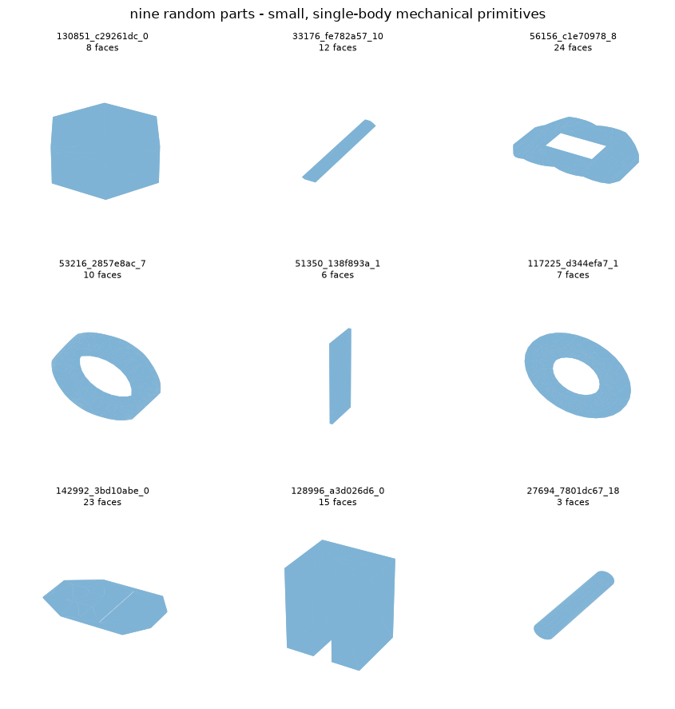

```python
import random

import matplotlib.pyplot as plt
from mpl_toolkits.mplot3d.art3d import Poly3DCollection


def render_part(ax, stem, color="#7fb3d5"):
    """Tessellate one part (deflection frozen in features.py) and draw it, axes off."""
    m = features.shape_to_trimesh(features.load_shape(f"fusion360subset/step/{stem}.stp"))
    v, t = np.array(m.vertices), np.array(m.faces)
    ax.add_collection3d(Poly3DCollection(v[t], facecolor=color, edgecolor="none", alpha=0.95))
    lo, hi = v.min(0), v.max(0)
    ctr, rad = (lo + hi) / 2, (hi - lo).max() / 2
    for dim, cc in zip("xyz", ctr):
        getattr(ax, f"set_{dim}lim")(cc - rad, cc + rad)
    ax.set_axis_off()


random.seed(1)
sample = random.sample(sorted(ds.stems.tolist()), 9)
fig = plt.figure(figsize=(9, 9))
for k, stem in enumerate(sample):
    ax = fig.add_subplot(3, 3, k + 1, projection="3d")
    render_part(ax, stem)
    n = len(open(f"fusion360subset/seg/{stem}.seg").read().split())
    ax.set_title(f"{stem}\n{n} faces", fontsize=8)
fig.suptitle("nine random parts - small, single-body mechanical primitives", fontsize=12)
plt.tight_layout()
plt.show()
```

Face count is the simplest measure of part complexity.

The distribution tells me the database is mostly simple parts: median 9 faces with a long tail to 130.

That shapes two later choices: per-face histograms will be coarse on 9-face parts, and complexity varies enough that my evaluation queries should cover the whole range, not just the easy majority.

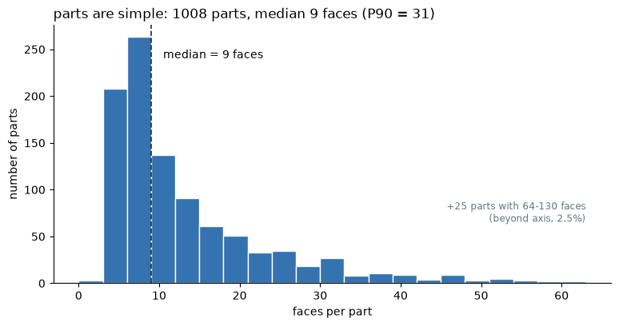

```python
fc = np.array([len(open(f"fusion360subset/seg/{s}.seg").read().split()) for s in ds.stems])
med, p90, mx = int(np.median(fc)), int(np.percentile(fc, 90)), int(fc.max())
tail = int((fc > 63).sum())

fig, ax = plt.subplots(figsize=(9, 4.2))
counts, _, _ = ax.hist(fc[fc <= 63], bins=range(0, 66, 3), color="#3572b0", edgecolor="white")
ax.axvline(med, color="#1f2937", ls="--", lw=1.2)
ax.text(med + 1.5, counts.max() * 0.95, f"median = {med} faces", fontsize=10, va="top")
ax.text(63, counts.max() * 0.25, f"+{tail} parts with 64-{mx} faces\n(beyond axis, {100 * tail / len(fc):.1f}%)",
        fontsize=8.5, color="#6b7280", ha="right")
ax.set_xlabel("faces per part")
ax.set_ylabel("number of parts")
ax.set_title(f"parts are simple: {len(fc)} parts, median {med} faces (P90 = {p90})", loc="left")
ax.spines[["top", "right"]].set_visible(False)
plt.savefig("figures/face_count_hist.png", dpi=110, bbox_inches="tight")
plt.show()
```

#### 1.2 The `.seg` labels:

The answer key per face

Line *i* of a `.seg` file is one integer: the modelling operation that created face *i* of the STEP file (8 classes — extrude/cut/revolve side+end faces, fillet, chamfer).

They record **which operation made each face**. One label per face, with no order or sequence: there is no build history or timeline in the file. They say nothing about shape. They are heavily skewed toward generic extrude faces.

Both properties drive the same decision: the labels serve as an **evaluation referee**, never as retrieval features (a signal that builds the features cannot also judge the results).

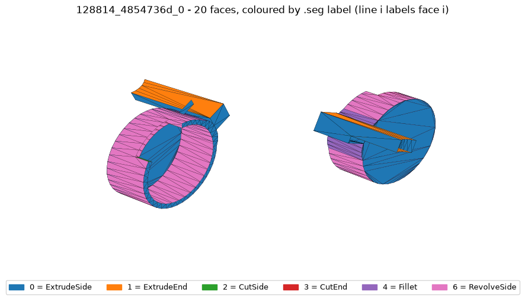

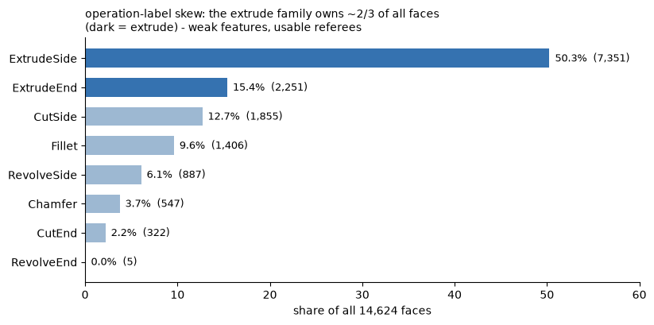

```python
import json as _json
from collections import Counter

from matplotlib.patches import Patch
from OCC.Core.BRep import BRep_Tool
from OCC.Core.BRepMesh import BRepMesh_IncrementalMesh
from OCC.Core.TopLoc import TopLoc_Location

seg_names = _json.load(open("fusion360subset/segment_names.json"))


def render_seg(stem, views=((25, 40), (25, 220))):
    """One part, faces coloured by their .seg operation label."""
    labels = [int(x) for x in open(f"fusion360subset/seg/{stem}.seg").read().split()]
    shape = features.load_shape(f"fusion360subset/step/{stem}.stp")
    BRepMesh_IncrementalMesh(shape, 0.05)
    cmap = plt.get_cmap("tab10")
    fig = plt.figure(figsize=(10, 5))
    for k, (elev, azim) in enumerate(views):
        ax = fig.add_subplot(1, len(views), k + 1, projection="3d")
        allv = []
        for fi, face in enumerate(features.iter_faces(shape)):
            loc = TopLoc_Location()
            tri = BRep_Tool.Triangulation(face, loc)
            if tri is None:
                continue
            trsf = loc.Transformation()
            vs = np.array([[tri.Node(i).Transformed(trsf).X(),
                            tri.Node(i).Transformed(trsf).Y(),
                            tri.Node(i).Transformed(trsf).Z()] for i in range(1, tri.NbNodes() + 1)])
            ts = np.array([tri.Triangle(i).Get() for i in range(1, tri.NbTriangles() + 1)]) - 1
            ax.add_collection3d(Poly3DCollection(vs[ts], facecolor=cmap(labels[fi]),
                                                 edgecolor="k", linewidths=0.15))
            allv.append(vs)
        v = np.vstack(allv)
        lo, hi = v.min(0), v.max(0)
        ctr, rad = (lo + hi) / 2, (hi - lo).max() / 2
        for dim, cc in zip("xyz", ctr):
            getattr(ax, f"set_{dim}lim")(cc - rad, cc + rad)
        ax.view_init(elev, azim)
        ax.set_axis_off()
    present = sorted(set(labels))
    fig.legend(handles=[Patch(color=cmap(i), label=f"{i} = {seg_names[i]}") for i in present],
               loc="lower center", ncol=6, fontsize=9)
    fig.suptitle(f"{stem} - {len(labels)} faces, coloured by .seg label (line i labels face i)")
    plt.savefig("figures/seg_explainer.png", dpi=110, bbox_inches="tight")
    plt.show()


render_seg("128814_4854736d_0")

cnt = Counter()
for s in ds.stems:
    cnt.update(int(x) for x in open(f"fusion360subset/seg/{s}.seg").read().split())
total = sum(cnt.values())
pairs = sorted(((seg_names[k], v) for k, v in cnt.items()), key=lambda x: -x[1])
labels_, vals = [p[0] for p in pairs][::-1], [100 * p[1] / total for p in pairs][::-1]

fig, ax = plt.subplots(figsize=(9, 4))
colors = ["#3572b0" if l in ("ExtrudeSide", "ExtrudeEnd") else "#9db8d2" for l in labels_]
bars = ax.barh(labels_, vals, color=colors, height=0.65)
for b, v, n in zip(bars, vals, [p[1] for p in pairs][::-1]):
    ax.text(b.get_width() + 0.6, b.get_y() + b.get_height() / 2, f"{v:.1f}%  ({n:,})", va="center", fontsize=9)
ax.set_xlabel(f"share of all {total:,} faces")
ax.set_xlim(0, 60)
ax.set_title("operation-label skew: the extrude family owns ~2/3 of all faces\n"
             "(dark = extrude) - weak features, usable referees", loc="left", fontsize=10)
ax.spines[["top", "right"]].set_visible(False)
plt.savefig("figures/seg_label_skew.png", dpi=110, bbox_inches="tight")
plt.show()
```

#### 1.3 Additional features: the 12-scalar block (v1 candidate)

[output not shown]

!! What the block sees that D2 cannot: **local identity**. A smooth ring and a notched ring have near-identical distance statistics (D2-blind) but different face-type mixes. Examples such as the notches are extra planes/cylinders. This is the ring-row finding from the visual sanity check, turned into a feature.

*bbox is axis-aligned, so ratios shift somewhat under rotation — a known approximation, acceptable at prototype level (noted as a limitation).

**Where does this come from?:**

*(1) named, published:*

- D2 is Osada et al. 2002 ("Shape Distributions")
- sphericity is Wadell 1935, a century-old measure from sedimentology

*(2) standard practice:* face-type mix and bounding-box aspect ratios are generalised descriptors of shape retrieval (input from lab members), and face types are input channels in modern b-rep networks (BRepNet, UV-Net).

*(3) pragmatic:* log₁₀(face count) is a standard complexity proxy. Log, because complexity differences matter as ratios (9→90 faces counts like 90→900), not as absolutes.

**Sphericity vs the sphere face-type, They are not the same signal:** sphericity $\Psi$ is GLOBAL mass proportion (volume vs area); the sphere face-type fraction is LOCAL surface math. A cube: $\Psi \approx 0.81$, zero sphere faces. A thin hemispherical shell: sphere faces present, $\Psi$ low. The figure below (regenerated by `make_scalar_figure.py`) shows all four groups on real database data.

```
saved figures/scalar_features_explainer.png
turned: 21797_69df08d5_8 [0.04 0.96 0.   0.   0.   0.   0.   0.  ] | boxy: 100623_9f3a73f2_0 [1. 0. 0. 0. 0. 0. 0. 0.]
sphericity picks: [('23053_139f2009_0', 0.09), ('48827_7d6ba23d_0', 0.32), ('23876_74957d38_21', 0.45), ('41973_0e5cd44c_7', 0.62), ('98606_cddce762_2', 0.87)]
```

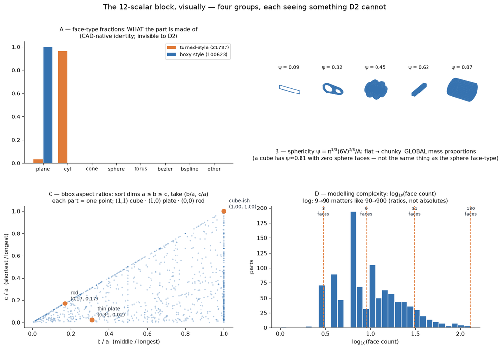

[figure not shown]

```python
from IPython.display import Image
%run make_scalar_figure.py
Image("figures/scalar_features_explainer.png")
```

#### 1.4 D2, and how one query works

Two generated diagrams: the full dataflow (offline extraction lane + query lane), then the D2 "dart game" step by step on real database parts.

Anchor numbers: ring↔ring d = 0.90 vs ring↔rod d = 5.83, about 6.5× separation between a same-family and a different-family match. Rotation and translation invariance come from measuring pair *distances* at all. Scale invariance comes from dividing by the part's own p99 distance: the 99th-percentile pair distance rather than the longest one, so a single outlying pair cannot stretch the axis.

**What D2 can and cannot do, per its own paper.** Osada et al. built shape distributions for coarse retrieval (separating broad shape classes in early-2000s model collections) and proposed a family of functions:

- D2 (pair distances)
- A3 (angle of three points)
- D3 (triangle area)
- D4 (tetrahedron volume).

Known limits:

- different shapes can produce near-identical histograms (shape → histogram is many-to-one)
- the histogram is a sampling estimate, so it carries noise
- the result depends on how distances are normalised, which is what my p99 choice answers
- it is blind to mirroring and to orientation, and it compares whole objects only (no partial matching)

I chose it as v0 for exactly the flip side: simple, invariant by construction, and cheap. Sections 6–8 measure where those limits cause problems.

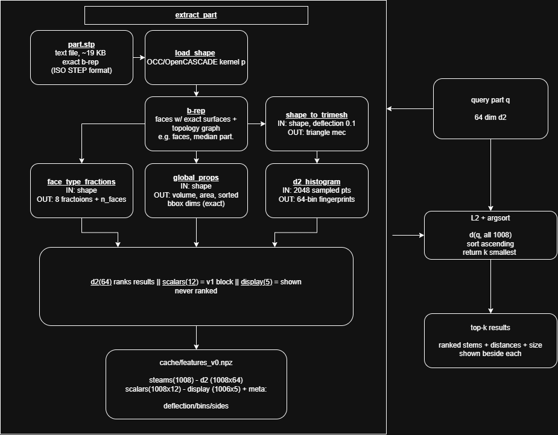

```python
# dataflow diagram maintained by hand (draw.io) - do not regenerate
from IPython.display import Image
Image("figures/pipeline_dataflow.drawio.png")
```

```
saved figures/method_explainer.png | ring-ring 0.90 vs ring-rod 5.83
```

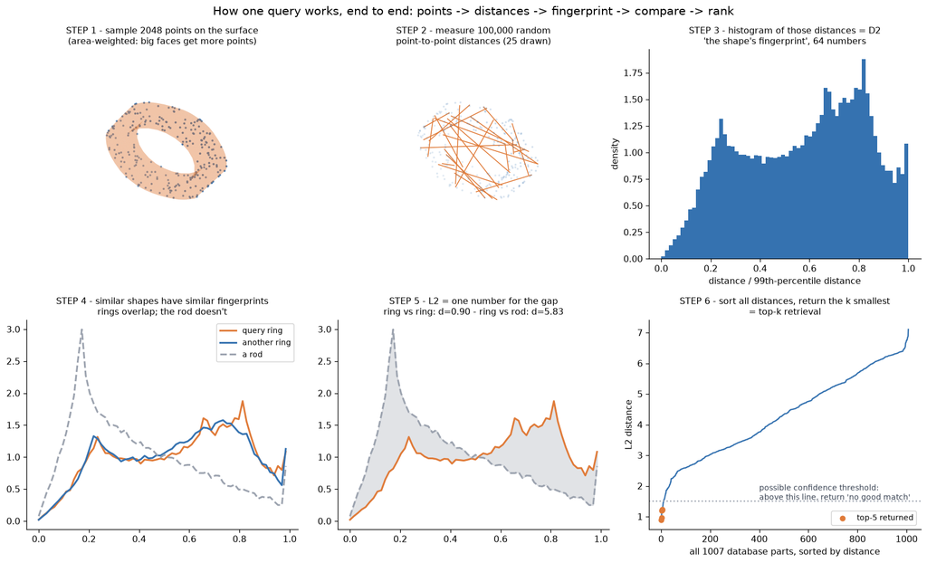

```python
%run make_method_figure.py
Image("figures/method_explainer.png")
```

### 2. Storage

Where do the fingerprints live, and what does one query cost against them? Worth asking explicitly, because the reflex answer -- a managed vector database -- is the wrong one at this scale, and being able to say why is more useful than having one.

**Choice: the cached numpy archive above (~0.5 MB) held in memory, with exact brute-force k-NN at query time. No vector database.**

Reasoning against this system: we have 1008 parts x 64-dim float fingerprints is ~0.5 MB. One query is a single vectorised subtraction over that matrix plus an argsort, well under a millisecond.

A managed vector database buys an ANN index — *approximate nearest neighbour*. Instead of comparing the query against every stored vector, a pre-built index groups the vectors in advance and searches only the promising groups: faster, occasionally wrong about the true nearest neighbour, and worth it only when "every vector" means millions.

At 1008 vectors there is nothing to skip, and it would add an account, network latency and an external dependency for zero retrieval benefit.

**BUT** if we were at ~10^5-10^6 parts, multi-user concurrent access, or latency requirements over a growing archive, an ANN index earns its keep — an in-process index first, and a managed store only if serving demands it. The design anticipates that: `retrieve_cad_models()` is a pure function of (query fingerprint, fingerprint matrix), so the storage layer can be swapped without touching the method.

### 3. Retrieval

#### 3.1 v0 implementation

```python
def retrieve_cad_models(query, ds: Dataset = ds, k: int = 5):
    """Top-k most relevant corpus parts for a query CAD model.

    query: a corpus stem (str) for an in-corpus query, or a path to any .stp file -
           an external query gets the identical extraction as the corpus.
    Returns a list of (stem, L2 distance, display sizes), closest first.
    """
    if isinstance(query, str) and query in ds.stems:
        q_d2 = ds.d2[ds.index(query)]
        exclude = query                      # a corpus query must not retrieve itself
    else:
        q_d2, _, _, _ = features.extract_part(query)
        exclude = None
    dist = np.linalg.norm(ds.d2 - q_d2, axis=1)   # L2 to every corpus fingerprint
    order = np.argsort(dist)                      # the ORDER of parts, closest first
    hits = [i for i in order if ds.stems[i] != exclude][:k]
    return [(str(ds.stems[i]), float(dist[i]), ds.display[i]) for i in hits]


# one query, end to end - a ring; size printed, never ranked
for stem, d, disp in retrieve_cad_models("53216_2857e8ac_7"):
    print(f"{stem:24s} d={d:5.2f}   bbox {disp[0]:5.1f} x {disp[1]:5.1f} x {disp[2]:5.1f} cm   vol {disp[3]:7.1f} cm3")
```

```
147630_7f858240_3        d= 0.90   bbox  19.9 x  18.6 x   4.3 cm   vol   773.3 cm3
72090_a3e21840_14        d= 0.96   bbox  20.0 x  20.0 x   7.1 cm   vol   898.3 cm3
23035_6087bb57_9         d= 1.19   bbox  20.0 x  20.0 x   3.5 cm   vol   710.9 cm3
33859_abb6d914_1         d= 1.21   bbox  21.6 x  21.6 x   3.7 cm   vol   505.4 cm3
93673_0ecfc82e_12        d= 1.23   bbox  20.0 x  18.9 x   6.7 cm   vol   818.0 cm3
```

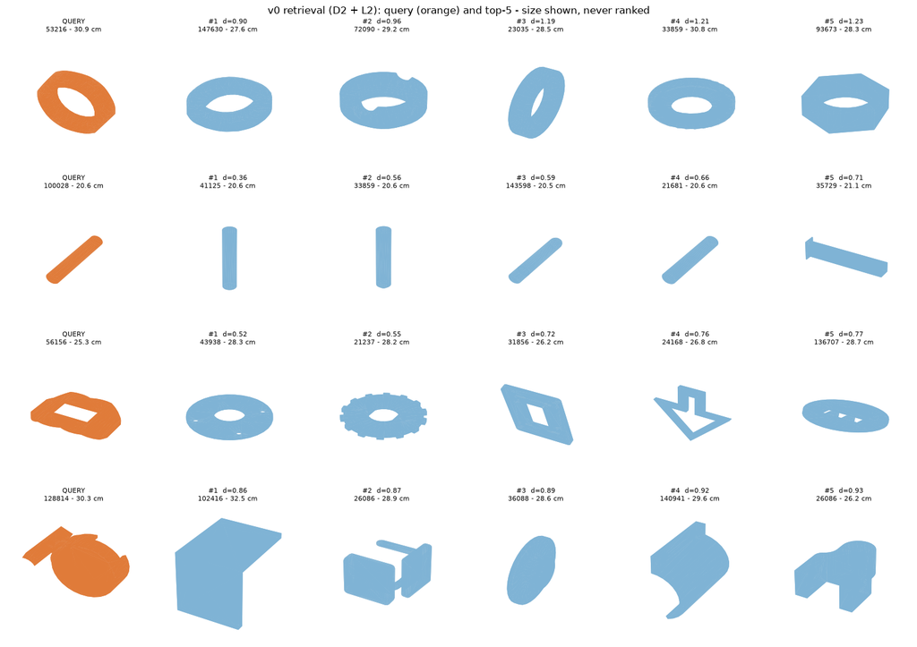

```python
def sanity_grid(queries, k=5, save=None):
    """Query (orange) + top-k per row; bbox diagonal printed under every part - shown, never ranked."""
    fig = plt.figure(figsize=(2.6 * (k + 1), 2.75 * len(queries)))
    for r, q in enumerate(queries):
        row = [(q, 0.0, ds.display[ds.index(q)])] + retrieve_cad_models(q, k=k)
        for c, (stem, dist, disp) in enumerate(row):
            ax = fig.add_subplot(len(queries), k + 1, r * (k + 1) + c + 1, projection="3d")
            render_part(ax, stem, "#e07b39" if c == 0 else "#7fb3d5")
            head = "QUERY" if c == 0 else f"#{c}  d={dist:.2f}"
            ax.set_title(f"{head}\n{stem.split('_')[0]} - {disp[4]:.1f} cm", fontsize=8)
    fig.suptitle("v0 retrieval (D2 + L2): query (orange) and top-5 - size shown, never ranked", fontsize=12)
    plt.tight_layout()
    if save:
        plt.savefig(save, dpi=110, bbox_inches="tight")
    plt.show()


sanity_grid(["53216_2857e8ac_7",    # ring
             "100028_0c3a8f1c_1",   # rod
             "56156_c1e70978_8",    # plate with rectangular hole
             "128814_4854736d_0"],  # revolve + tab (the honest failure case)
            save="figures/retrieval_v0_sanity.png")
```

#### 3.2 Visual sanity check

- **Rows 1–2 (ring, rod): good.** Hits are the right shape family across different orientations. Rod distances run 0.36–0.71: low, and with a clear spread, so the system is discriminating rather than calling everything equally close.
- **Rows 3–4: weak, honestly.** The complex revolve-with-tab query returns visually unrelated parts. Distances betray it: 0.86–0.93, high *and bunched*. Nothing really stands out, the system has found nothing but returns something anyway. Two distinct causes to keep apart:
  - Database coverage (1008 parts may hold no true neighbour for an unusual part)
  - D2 summarisation (a global distance histogram averages away mixed local structure).
- **Follow-ups:** a distance threshold, basically a "no good match in the archive" as a first-class answer. Additionally now adding the v1 scalar block (a notched ring differs from a smooth one in face types, invisible to D2).

### 4. Evaluation

**One obstacle shapes the whole project: the dataset carries no relevance labels.** Nobody has ever marked "for query A, part B is a good retrieval."

No single test can therefore prove the system works.

My design instead assembles **four families of indirect evidence**, each judged against a stated control, each carrying an explicit *cannot-show* clause.

| # | Test | What it shows | What it cannot show |
| --- | --- | --- | --- |
| 1 | **Sanity floor:** every part must retrieve itself at distance 0 | System not broken (basic and necessary condition) | Passing proves almost nothing, finding an exact copy is trivial solution |
| 2 | **Stability:** re-fingerprint the database with new random darts or a changed tessellation, and the part must still find itself | D2 is a sampling *estimate*, so noise is guaranteed (mentioned before), this measures whether rankings survive it | Stability, not correctness (a stably *wrong* system passes) |
| 3 | **Seg referee:** per-part 8-bin operation-fraction histogram, then L2 between the query's histogram and each top-5 hit's (lower = better), judged against a **random-5 control** | Labels never touched the features, so beating the zero-intelligence control is *independent* evidence | Construction similarity is a weak proxy for functional reuse, label skew (65% extrude) inflates the control's score |
| 4 | **Confidence signal:** correlate nearest-neighbour distance with referee distance | If far ⇒ measurably worse, "no good match in the archive" becomes a first-class answer | Justifies the idea, any specific cutoff stays a judgement call |

**The control.** Random-5 retrieval is what a system with zero intelligence scores. Comparing against it turns a lone number into evidence.

**Hyperparameters:** deflection 0.1 cm (~0.5% of a typical 20 cm part), 2048 samples, 100k pairs, 64 bins are the standard values used by Osada et al. (2002). Set first by recipe, then **validated empirically by Test 2**, which perturbs exactly these parameters. k=5 is just a UI-scale choice, not necessarily method parameter.

#### 4.1 Tests 1 and 2 — sanity floor and stability

```python
import evaluate

ok = evaluate.self_retrieval(ds.d2)
print(f"Test 1 - sanity floor: {ok:.1%} of 1008 parts retrieve themselves first (required: 100%)")
```

```
Test 1 - sanity floor: 100.0% of 1008 parts retrieve themselves first (required: 100%)
```

```python
for label, tag, defl, seed in [
        ("new darts (seed 0 -> 1)", "seed1", features.DEFLECTION, 1),
        ("finer tessellation (0.1 -> 0.05)", "defl005", 0.05, features.SEED)]:
    Dv = evaluate.build_variant_cache(tag, defl, seed)   # ~1 min per variant, then cached
    r = evaluate.perturbation_ranks(ds.d2, Dv)
    print(f"Test 2 - stability, {label}:  self rank-1 {np.mean(r == 1):.1%}"
          f" | within top-5 {np.mean(r <= 5):.1%} | failures {int((r > 5).sum())}/1008 | worst rank {r.max()}")
```

```
Test 2 - stability, new darts (seed 0 -> 1):  self rank-1 86.2% | within top-5 97.1% | failures 29/1008 | worst rank 20
Test 2 - stability, finer tessellation (0.1 -> 0.05):  self rank-1 97.6% | within top-5 99.3% | failures 7/1008 | worst rank 15
```

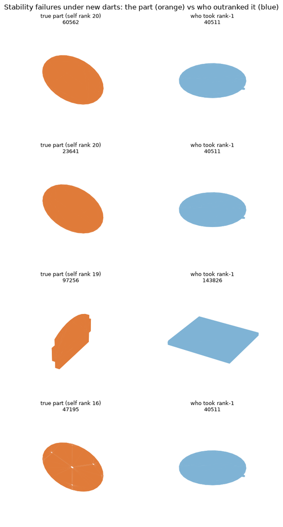

```python
# who are the failures, and who beat them? (uniqueness check)
Dv = evaluate.build_variant_cache("seed1", features.DEFLECTION, 1)
fails = []
for i in range(len(ds.d2)):
    d = np.linalg.norm(ds.d2 - Dv[i], axis=1)
    order = np.argsort(d)
    rank = int(order.tolist().index(i)) + 1
    if rank > 5:
        fails.append((rank, i, int(order[0])))
fails.sort(reverse=True)

fig = plt.figure(figsize=(7.5, 13))
for r_, (rank, i, j) in enumerate(fails[:4]):
    ax = fig.add_subplot(4, 2, 2 * r_ + 1, projection="3d")
    render_part(ax, str(ds.stems[i]), "#e07b39")
    ax.set_title(f"true part (self rank {rank})\n{str(ds.stems[i]).split('_')[0]}", fontsize=9)
    ax = fig.add_subplot(4, 2, 2 * r_ + 2, projection="3d")
    render_part(ax, str(ds.stems[j]))
    ax.set_title(f"who took rank-1\n{str(ds.stems[j]).split('_')[0]}", fontsize=9)
fig.suptitle("Stability failures under new darts: the part (orange) vs who outranked it (blue)", fontsize=12)
plt.tight_layout()
plt.savefig("figures/stability_failures.png", dpi=110, bbox_inches="tight")
plt.show()
```

**Tests 1–2 verdicts**

The floor holds: all 1008 parts retrieve themselves at distance zero.

The stability test perturbs and asks: does the part still find itself?

"Finding itself" in this case means the original part appears in the **top-5** when I query with the perturbed fingerprint. A **failure** means it no longer does.

A tessellation variant (deflection 0.1 → 0.05) earns its place by separating the two noise sources in the pipeline. Mesh resolution turns out nearly harmless: 7 of 1008 parts fall out of their own top-5, and since database and query always share one frozen deflection, consistency is unaffected so 0.1 stays. The dart seed is the real nuisance: 29 of 1008 parts (2.9%) lose their top-5 place, worst rank 20.

What does **outranked** mean here? Another part sits closer to the perturbed fingerprint than the original does. The inspection above shows why: every examined failure is a near-duplicate family — thin discs beaten by other thin discs, plates by plates. The fingerprint moved a little under new darts, and a near-twin was already sitting almost as close.

**Verdict:** the failures expose a false assumption, not a broken descriptor. I assumed D2 is consistent *and unique* per part. It is consistent under noise (97.1% keep their top-5). It is not unique where the database holds near-identical parts.

For retrieval: a twin outranking the original is harmless, arguably correct. For exact-identity lookup it would not be.

#### 4.2 Test 3 — the seg referee

Tests 1/2 never measure whether retrieved parts are any *good*. A system stably returning garbage passes both.

Test 3 is used as the quality measure, and it must use evidence the ranking never touched (or else it would be as if we graded our own homework).

So we use the evidence in the `.seg` labels, held out of the features as a referee. The Block-1 relevance decision precisely for this moment: **do our top-5 share the query's construction profile more than five random parts would?**

Mechanics: for every part a 8-bin operation-fraction histogram → L2 between query and each top-5 hit (lower = better) → mean over the five per query → judged against the random-5 zero-intelligence control.

Why the mean of five and not, say, the best hit: the engineer sees all five results, so the whole set is the product. The mean keeps every hit accountable — min would grade only the best suggestion and forgive four bad ones, max would punish one stray.

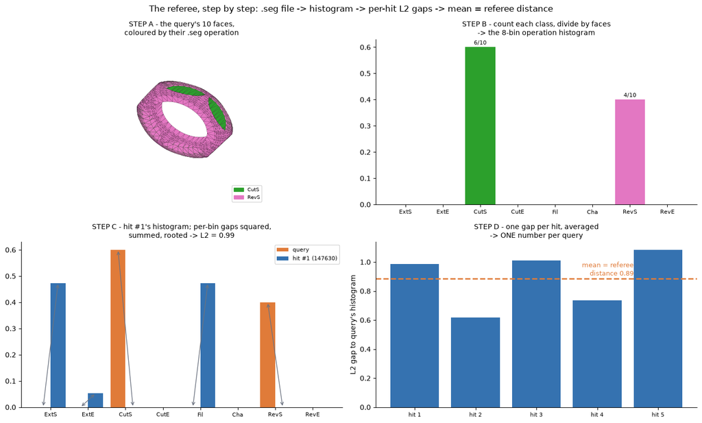

```python
# The referee, step by step, on ONE query - where the histogram lives
SEG = evaluate.seg_histograms(ds.stems)
OPS = ["ExtS", "ExtE", "CutS", "CutE", "Fil", "Cha", "RevS", "RevE"]

qs = "53216_2857e8ac_7"                       # the washer query
q = ds.index(qs)
labels_q = [int(x) for x in open(f"fusion360subset/seg/{qs}.seg").read().split()]
hits = [ds.index(s) for s, _, _ in retrieve_cad_models(qs)]
gaps = np.linalg.norm(SEG[hits] - SEG[q], axis=1)
cmap = plt.get_cmap("tab10")

fig = plt.figure(figsize=(14, 8.5))

# STEP A - raw material: the query's faces, coloured by operation label
axA = fig.add_subplot(2, 2, 1, projection="3d")
shape = features.load_shape(f"fusion360subset/step/{qs}.stp")
BRepMesh_IncrementalMesh(shape, 0.05)
allv = []
for fi, face in enumerate(features.iter_faces(shape)):
    loc = TopLoc_Location()
    tri = BRep_Tool.Triangulation(face, loc)
    if tri is None:
        continue
    trsf = loc.Transformation()
    vs = np.array([[tri.Node(i).Transformed(trsf).X(), tri.Node(i).Transformed(trsf).Y(),
                    tri.Node(i).Transformed(trsf).Z()] for i in range(1, tri.NbNodes() + 1)])
    ts = np.array([tri.Triangle(i).Get() for i in range(1, tri.NbTriangles() + 1)]) - 1
    axA.add_collection3d(Poly3DCollection(vs[ts], facecolor=cmap(labels_q[fi]), edgecolor="k", linewidths=0.1))
    allv.append(vs)
v = np.vstack(allv)
lo, hi = v.min(0), v.max(0)
ctr, rad = (lo + hi) / 2, (hi - lo).max() / 2
for dim, cc in zip("xyz", ctr):
    getattr(axA, f"set_{dim}lim")(cc - rad, cc + rad)
axA.set_axis_off()
axA.legend(handles=[Patch(color=cmap(i), label=OPS[i]) for i in sorted(set(labels_q))],
           fontsize=7, loc="lower right")
axA.set_title(f"STEP A - the query's {len(labels_q)} faces,\ncoloured by their .seg operation", fontsize=10)

# STEP B - count classes, divide by face count -> THE histogram
axB = fig.add_subplot(2, 2, 2)
x = np.arange(8)
axB.bar(x, SEG[q], color=[cmap(i) for i in range(8)])
for i, val in enumerate(SEG[q]):
    if val > 0:
        axB.text(i, val + 0.01, f"{int(round(val * len(labels_q)))}/{len(labels_q)}", ha="center", fontsize=8)
axB.set_xticks(x, OPS, fontsize=8)
axB.set_title("STEP B - count each class, divide by faces\n-> the 8-bin operation histogram", fontsize=10)
axB.spines[["top", "right"]].set_visible(False)

# STEP C - hit #1's histogram next to it; per-bin gaps; L2 = one number
axC = fig.add_subplot(2, 2, 3)
h1 = hits[0]
axC.bar(x - 0.2, SEG[q], 0.4, color="#e07b39", label="query")
axC.bar(x + 0.2, SEG[h1], 0.4, color="#3572b0", label=f"hit #1 ({str(ds.stems[h1]).split('_')[0]})")
for i in range(8):
    if abs(SEG[q][i] - SEG[h1][i]) > 0.02:
        axC.annotate("", (i - 0.2, SEG[q][i]), (i + 0.2, SEG[h1][i]),
                     arrowprops=dict(arrowstyle="<->", color="#6b7280", lw=1))
axC.set_xticks(x, OPS, fontsize=8)
axC.legend(fontsize=8)
axC.set_title(f"STEP C - hit #1's histogram; per-bin gaps squared,\nsummed, rooted -> L2 = {gaps[0]:.2f}", fontsize=10)
axC.spines[["top", "right"]].set_visible(False)

# STEP D - five hits -> five gaps -> mean = referee distance
axD = fig.add_subplot(2, 2, 4)
axD.bar(range(1, 6), gaps, color="#3572b0")
axD.axhline(gaps.mean(), color="#e07b39", ls="--", lw=2)
axD.text(4.6, gaps.mean() + 0.02, f"mean = referee\ndistance {gaps.mean():.2f}", color="#e07b39", fontsize=9, ha="right")
axD.set_xticks(range(1, 6), [f"hit {i}" for i in range(1, 6)], fontsize=8)
axD.set_ylabel("L2 gap to query's histogram")
axD.set_title("STEP D - one gap per hit, averaged\n-> ONE number per query", fontsize=10)
axD.spines[["top", "right"]].set_visible(False)

fig.suptitle("The referee, step by step: .seg file -> histogram -> per-hit L2 gaps -> mean = referee distance", fontsize=12)
plt.tight_layout()
plt.savefig("figures/referee_step_by_step.png", dpi=110, bbox_inches="tight")
plt.show()
```

```
Test 3 - seg referee (L2 on 8-bin operation histograms, LOWER = better)
  v0 top-5 mean referee distance : 0.545
  random-5 control               : 0.592
```

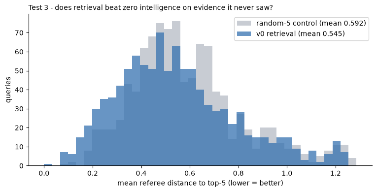

```python
SEG = evaluate.seg_histograms(ds.stems)

ref_v0 = evaluate.seg_referee(ds.d2, SEG)                          # our system's top-5
ref_rnd = evaluate.seg_referee(ds.d2, SEG, random_baseline=True)   # zero-intelligence control

print("Test 3 - seg referee (L2 on 8-bin operation histograms, LOWER = better)")
print(f"  v0 top-5 mean referee distance : {ref_v0.mean():.3f}")
print(f"  random-5 control               : {ref_rnd.mean():.3f}")

fig, ax = plt.subplots(figsize=(9, 4))
bins = np.linspace(0, float(max(ref_v0.max(), ref_rnd.max())), 40)
ax.hist(ref_rnd, bins=bins, alpha=0.55, color="#9ca3af", label=f"random-5 control (mean {ref_rnd.mean():.3f})")
ax.hist(ref_v0, bins=bins, alpha=0.75, color="#3572b0", label=f"v0 retrieval (mean {ref_v0.mean():.3f})")
ax.set_xlabel("mean referee distance to top-5 (lower = better)")
ax.set_ylabel("queries")
ax.legend()
ax.set_title("Test 3 - does retrieval beat zero intelligence on evidence it never saw?", loc="left", fontsize=10)
ax.spines[["top", "right"]].set_visible(False)
plt.savefig("figures/referee_v0_vs_random.png", dpi=110, bbox_inches="tight")
plt.show()
```

```python
# A skeptic's attack: "0.545 vs 0.592 on overlapping histograms - noise."
# pairing test: every query has BOTH scores, so count per-query wins.
# Under "no effect", beating your own control is a coin flip -> ~504/1008 expected.
from scipy.stats import binomtest

wins = int(np.sum(ref_v0 < ref_rnd))
ties = int(np.sum(ref_v0 == ref_rnd))
n = len(ref_v0)
bt = binomtest(wins, n - ties, 0.5)
print(f"paired per-query comparison ({n} queries):")
print(f"  v0 beats its own control : {wins}/{n} ({wins / n:.1%})  [coin-flip expectation ~{(n - ties) // 2}]")
print(f"  median paired difference : {np.median(ref_v0 - ref_rnd):+.3f}  (negative = v0 better)")
print(f"  sign-test p-value        : {bt.pvalue:.2e}")
```

```
paired per-query comparison (1008 queries):
  v0 beats its own control : 601/1008 (59.6%)  [coin-flip expectation ~504]
  median paired difference : -0.036  (negative = v0 better)
  sign-test p-value        : 1.08e-09
```

**Test 3 verdict.** The sign test rules out chance: 601 wins out of 1008 paired queries, p ≈ 10⁻⁹. The effect itself is **modest**, 59.6% of queries won and a median improvement of 0.036, and it is measured on a ruler that squashes real differences.

Label skew pushes even random pairs close together, so a modest gap on this scale understates the true difference. *Systematic, modest and understated: one evidence family of four, not a proof of relevance on its own.*

v0 carries more mass at low referee distances (≈0.2–0.6), while the random control bulges around 0.5–0.7, acting as the "average profile".

Final statement: **the p-value rules out chance, and the effect size (59.6% of queries, −0.036) puts the size of the win at "modest".**

**The two axes of Test 4:**

- **NN distance** (x-axis) uses ONLY the fingerprints: for a query, the L2 distance between its 64-bin D2 fingerprint and the *closest other part's* fingerprint. Small = a near-twin exists; large = even the best match is a stretch.
- **Referee distance** (y-axis) uses ONLY the labels: I take the query's top-5, compute L2 between the query's 8-bin operation histogram and each hit's, average the five. Plain words: *"how different is the construction recipe of what I retrieved?"*

I do this because the two numbers come from **disjoint data** (geometry sampling vs modelling labels), a correlation between them is informative rather than mechanical.

The cell below makes both concrete on one good query and one bad one.

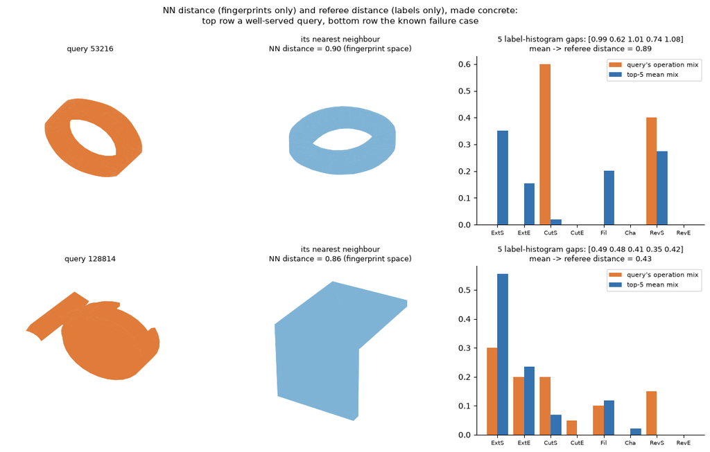

```python
def nn_of(stem):
    """Nearest non-self neighbour of a corpus part, with the distance."""
    q = ds.index(stem)
    d = np.linalg.norm(ds.d2 - ds.d2[q], axis=1)
    d[q] = np.inf
    j = int(np.argmin(d))
    return str(ds.stems[j]), float(d[j])


def referee_of(stem, k=5):
    """Referee distance of a query: mean L2 between its seg histogram and its top-k's."""
    q = ds.index(stem)
    hits = [ds.index(s) for s, _, _ in retrieve_cad_models(stem, k=k)]
    gaps = np.linalg.norm(SEG[hits] - SEG[q], axis=1)
    return float(gaps.mean()), gaps


OPS = ["ExtS", "ExtE", "CutS", "CutE", "Fil", "Cha", "RevS", "RevE"]
examples = ["53216_2857e8ac_7", "128814_4854736d_0"]     # a good query, the known bad one

fig = plt.figure(figsize=(13, 8))
for r, qs in enumerate(examples):
    nn_stem, nn_d = nn_of(qs)
    ref_mean, gaps = referee_of(qs)
    ax = fig.add_subplot(2, 3, 3 * r + 1, projection="3d")
    render_part(ax, qs, "#e07b39")
    ax.set_title(f"query {qs.split('_')[0]}", fontsize=9)
    ax = fig.add_subplot(2, 3, 3 * r + 2, projection="3d")
    render_part(ax, nn_stem)
    ax.set_title(f"its nearest neighbour\nNN distance = {nn_d:.2f} (fingerprint space)", fontsize=9)
    ax = fig.add_subplot(2, 3, 3 * r + 3)
    q = ds.index(qs)
    hits = [ds.index(s) for s, _, _ in retrieve_cad_models(qs)]
    x = np.arange(8)
    ax.bar(x - 0.2, SEG[q], 0.4, color="#e07b39", label="query's operation mix")
    ax.bar(x + 0.2, SEG[hits].mean(0), 0.4, color="#3572b0", label="top-5 mean mix")
    ax.set_xticks(x, OPS, fontsize=7.5)
    ax.legend(fontsize=8)
    ax.set_title(f"5 label-histogram gaps: {np.array2string(gaps, precision=2)}\n"
                 f"mean -> referee distance = {ref_mean:.2f}", fontsize=9)
    ax.spines[["top", "right"]].set_visible(False)
fig.suptitle("NN distance (fingerprints only) and referee distance (labels only), made concrete:\n"
             "top row a well-served query, bottom row the known failure case", fontsize=11)
plt.tight_layout()
plt.savefig("figures/test4_axes_explainer.png", dpi=110, bbox_inches="tight")
plt.show()
```

The example above exposed a structural weakness of the referee. The query washer was built **revolve + cut**. Its retrieved washers, visually perfect, were built **extrude + fillet**.

Same shape, different recipe. This is because **shape → construction is a many-to-one mapping**: one geometry, several modelling routes.

The referee therefore *punishes some correct retrievals*, and unfortunately Test 3's "modest" gap is understated on my side **twice**: once by label-skew compression, once by recipe ambiguity.

When referee and retrieval disagree, it is not automatically the retrieval that is wrong. This is a limitation of the proxy.

It also means the referee is **not a neutral judge** for the upcoming v0-vs-v1 comparison: v1's scalar block contains face-type fractions, and face types correlate with operations (RevolveSide faces are cylinders, cones and tori, and fillet faces are cylindrical or toroidal blends).

So any v1 referee win needs corroboration from **label-free** evidence.

#### 4.3 Test 4 — the confidence signal

The failure row in the visual sanity check betrayed itself through its *distances*: high and bunched, "found nothing but returning something anyway." Test 4 formalises that observation: per query, does the **nearest-neighbour distance** (how far the closest match sits in fingerprint pace) predict the **referee distance** (Test 3's quality score)?

If yes, distance becomes a usable confidence signal, and "no good match in the archive" earns the right to be a first-class answer. Spearman rank correlation, because we care about "farther ⇒ worse", not about linearity.

```
Test 4 - Spearman(NN distance, referee distance): rho = +0.331  (p = 3.4e-27)
```

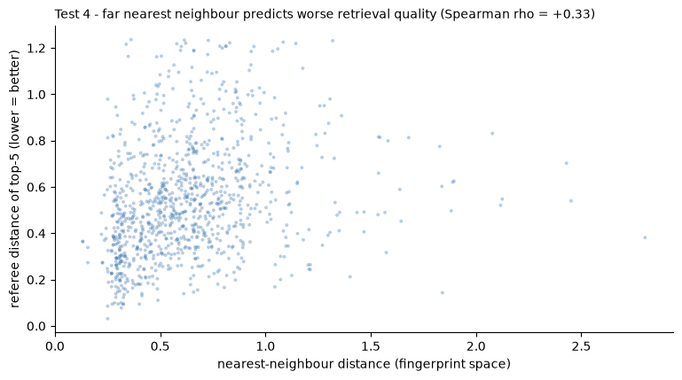

```python
from scipy.stats import spearmanr

nn = evaluate.nn_distances(ds.d2)              # distance to closest non-self neighbour
rho, pval = spearmanr(nn, ref_v0)
print(f"Test 4 - Spearman(NN distance, referee distance): rho = {rho:+.3f}  (p = {pval:.1e})")

fig, ax = plt.subplots(figsize=(9, 4.5))
ax.scatter(nn, ref_v0, s=8, alpha=0.35, color="#3572b0", edgecolors="none")
ax.set_xlabel("nearest-neighbour distance (fingerprint space)")
ax.set_ylabel("referee distance of top-5 (lower = better)")
ax.set_title(f"Test 4 - far nearest neighbour predicts worse retrieval quality "
             f"(Spearman rho = {rho:+.2f})", loc="left", fontsize=10)
ax.spines[["top", "right"]].set_visible(False)
plt.savefig("figures/threshold_correlation.png", dpi=110, bbox_inches="tight")
plt.show()
```

### 5. v0 vs v1

v1 adds the 12-scalar block to the fingerprint (z-scored per dimension, each block divided by √dims so the 64 D2 bins and the 12 scalars carry comparable weight).

The comparison has a **declared bias**: the referee scores construction-recipe similarity, and v1's face-type fractions are *cousins of the labels* (round faces ↔ revolve/fillet, flat ↔ extrude), meaning the judge is related to one contestant.

So the protocol is: referee verdict **plus two label-free corroborators** we already trust. The stability test and the visual sanity grid. v1 is adopted only if the clean witnesses agree.

```python
# v1 vectors: z-parameters FIT on the base corpus, applied to any variant
def zfit(X):
    mu, sd = X.mean(0), X.std(0)
    sd[sd == 0] = 1.0
    return mu, sd

mu_d2, sd_d2 = zfit(ds.d2)
mu_sc, sd_sc = zfit(ds.scalars)

def v1_transform(D2m, SCm):
    return np.hstack([(D2m - mu_d2) / sd_d2 / np.sqrt(D2m.shape[1]),
                      (SCm - mu_sc) / sd_sc / np.sqrt(SCm.shape[1])])

V1 = v1_transform(ds.d2, ds.scalars)

# witness 1 (biased, declared): the seg referee, paired against v0
ref_v1 = evaluate.seg_referee(V1, SEG)
wins_v1 = int(np.sum(ref_v1 < ref_v0))
from scipy.stats import binomtest
bt = binomtest(wins_v1, len(ref_v1) - int(np.sum(ref_v1 == ref_v0)), 0.5)
print(f"referee (biased judge): v1 {ref_v1.mean():.3f} vs v0 {ref_v0.mean():.3f} vs random {ref_rnd.mean():.3f}")
print(f"  paired: v1 beats v0 on {wins_v1}/{len(ref_v1)} queries ({wins_v1/len(ref_v1):.1%}), sign-test p = {bt.pvalue:.1e}")
```

```
referee (biased judge): v1 0.401 vs v0 0.545 vs random 0.592
  paired: v1 beats v0 on 789/1008 queries (78.3%), sign-test p = 1.5e-77
```

```python
# witness 2 (label-free): stability under new darts - scalars are deterministic,
# only the D2 block moves, so v1 should hold rank at least as well as v0
D2v = evaluate.build_variant_cache("seed1", features.DEFLECTION, 1)
V1v = v1_transform(D2v, ds.scalars)
r_v0 = evaluate.perturbation_ranks(ds.d2, D2v)
r_v1 = evaluate.perturbation_ranks(V1, V1v)
print(f"stability under new darts:  v0 rank-1 {np.mean(r_v0 == 1):.1%} / top-5 {np.mean(r_v0 <= 5):.1%}"
      f"   ->   v1 rank-1 {np.mean(r_v1 == 1):.1%} / top-5 {np.mean(r_v1 <= 5):.1%}")
```

```
stability under new darts:  v0 rank-1 86.2% / top-5 97.1%   ->   v1 rank-1 98.0% / top-5 100.0%
```

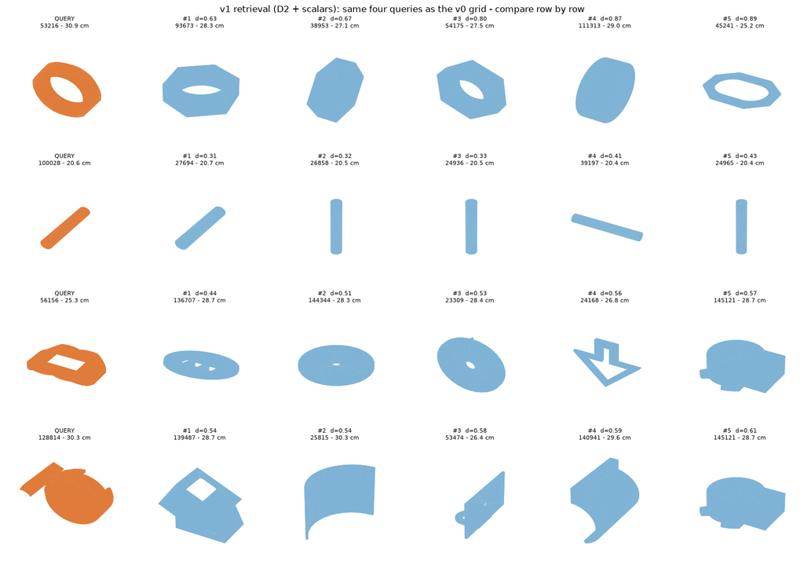

```python
# witness 3 (label-free): the visual sanity grid, v1 edition - same four queries
def retrieve_v1(stem, k=5):
    q = ds.index(stem)
    d = np.linalg.norm(V1 - V1[q], axis=1)
    order = np.argsort(d)
    hits = [i for i in order if i != q][:k]
    return [(str(ds.stems[i]), float(d[i]), ds.display[i]) for i in hits]

queries = ["53216_2857e8ac_7", "100028_0c3a8f1c_1", "56156_c1e70978_8", "128814_4854736d_0"]
fig = plt.figure(figsize=(15.6, 11))
for r, qs in enumerate(queries):
    row = [(qs, 0.0, ds.display[ds.index(qs)])] + retrieve_v1(qs)
    for c, (stem, dist, disp) in enumerate(row):
        ax = fig.add_subplot(4, 6, r * 6 + c + 1, projection="3d")
        render_part(ax, stem, "#e07b39" if c == 0 else "#7fb3d5")
        head = "QUERY" if c == 0 else f"#{c}  d={dist:.2f}"
        ax.set_title(f"{head}\n{stem.split('_')[0]} - {disp[4]:.1f} cm", fontsize=8)
fig.suptitle("v1 retrieval (D2 + scalars): same four queries as the v0 grid - compare row by row", fontsize=12)
plt.tight_layout()
plt.savefig("figures/retrieval_v1_sanity.png", dpi=110, bbox_inches="tight")
plt.show()
```

### 5.1 Verdict

**stability** (label-free): v1 clearly better. 98.0% rank-1, 100% top-5 under new darts, because the exact-b-rep scalars anchor the fingerprint against sampling noise.

**Referee** (bias declared): v1 by a landslide. 0.401 vs 0.545, 78.3% of paired queries, p ≈ 10⁻⁷⁷. **BUT** the judge is related to this contestant, so part of the margin is family resemblance.

**Shape fidelity** (label-free): v0 better on the ring row. Five true rings, where v1 admits two hole-less parts. Tied elsewhere, and neither rescues the hard failure case.

**Decision: keep both, with v0 as the default.** They are two *working definitions* of the same relevance definition from the problem restatement's layer-chain: **v0 optimises shape-relevance** (the declared definition), **v1 leans toward construction-relevance** and buys measurable stability. Which one to serve depends on the engineer's task — "find me this geometry to reuse" (v0) vs "find parts made like mine" (v1). Exposing that choice with the evidence above is the honest design. Collapsing it silently into one number would hide a real trade-off.

**Test 4 verdict and the confidence design (the ruling: gauge everywhere, one conservative line).** The correlation is real, because the sign is unambiguous at n = 1008 (Spearman ρ = +0.33, p ≈ 10⁻²⁷). Its strength is *moderate*.

The scatter is wide, so distance informs but does not guarantee. That is enough to justify shipping **nearest-neighbour distance as a confidence gauge beside every result**, plus a **single conservative flag** in the far tail (provisionally the 90th percentile of database NN distances), where retrievals are measurably worse and visibly unusable: there, *"no good match in the archive"* is the more honest answer than five bad suggestions.

The flag's exact position is documented as provisional. Tuning it is a product decision that needs real engineers, because the right line depends on their cost of a junk suggestion vs a missed one.

the true target of retrieval-for-reuse and relevance is **remaining work** → "how many edits from the retrieved part to what I need."

Measuring that directly needs construction histories, which the upstream Fusion 360 Gallery ships and our subset does not, so geometric similarity serves as the initial proxy.

The buried assumption *similar shape ⇒ few edits*.

The two kept systems hedge that assumption from both sides: v0 approximates it through shape, v1 through construction.

```python
# The confidence design, live: gauge on every result, conservative flag in the far tail
FLAG_PCTL = 90                                     # provisional - a product knob, not a method constant
flag_line = float(np.percentile(nn, FLAG_PCTL))

def retrieve_with_confidence(stem, k=5):
    q = ds.index(stem)
    d = np.linalg.norm(ds.d2 - ds.d2[q], axis=1)
    d[q] = np.inf
    nn_d = float(d.min())
    pctl = float((nn < nn_d).mean() * 100)
    flagged = nn_d > flag_line
    print(f"query {stem} | NN distance {nn_d:.2f} (percentile {pctl:.0f}) "
          f"{'*** LOW CONFIDENCE - archive may hold no good match ***' if flagged else '- confidence OK'}")
    for s, dist, disp in retrieve_cad_models(stem, k=k):
        print(f"   {s:26s} d={dist:5.2f}  bbox {disp[0]:5.1f} x {disp[1]:5.1f} x {disp[2]:5.1f} cm")

retrieve_with_confidence("53216_2857e8ac_7")     # the washer - served well
print()
retrieve_with_confidence("128814_4854736d_0")    # the known failure case
print()
far_query = str(ds.stems[int(np.argmax(nn))])        # the corpus's loneliest part
retrieve_with_confidence(far_query)                   # the flag actually firing
```

```
query 53216_2857e8ac_7 | NN distance 0.90 (percentile 87) - confidence OK
   147630_7f858240_3          d= 0.90  bbox  19.9 x  18.6 x   4.3 cm
   72090_a3e21840_14          d= 0.96  bbox  20.0 x  20.0 x   7.1 cm
   23035_6087bb57_9           d= 1.19  bbox  20.0 x  20.0 x   3.5 cm
   33859_abb6d914_1           d= 1.21  bbox  21.6 x  21.6 x   3.7 cm
   93673_0ecfc82e_12          d= 1.23  bbox  20.0 x  18.9 x   6.7 cm

query 128814_4854736d_0 | NN distance 0.86 (percentile 81) - confidence OK
   102416_b74464a2_0          d= 0.86  bbox  20.0 x  20.0 x  16.0 cm
   26086_bf892d7f_19          d= 0.87  bbox  20.0 x  15.1 x  14.4 cm
   36088_1ea9c8a9_4           d= 0.89  bbox  20.0 x  20.0 x   4.1 cm
   140941_0515199a_6          d= 0.92  bbox  20.0 x  19.9 x   9.1 cm
   26086_bf892d7f_14          d= 0.93  bbox  20.0 x  14.7 x   8.4 cm

query 41115_3ce6b43c_1 | NN distance 2.80 (percentile 100) *** LOW CONFIDENCE - archive may hold no good match ***
   45241_7a955ec1_30          d= 2.80  bbox  20.0 x  15.2 x   0.7 cm
   21237_7887a24b_28          d= 2.91  bbox  20.0 x  20.0 x   2.7 cm
   146890_bd415c5e_2          d= 2.93  bbox  20.0 x  14.1 x   2.9 cm
   82616_c8f6514c_1           d= 3.00  bbox  20.0 x  13.8 x   0.6 cm
   143014_390cd964_1          d= 3.05  bbox  20.0 x  13.7 x   0.4 cm
```

The third query shows the flag firing: for the database's most isolated part, every neighbour is beyond the 90th-percentile line, and the honest answer is "no good match in the archive" rather than five poor suggestions.

**What this demo shows:** the known failure case sits at percentile 81, *below* the conservative flag, so it comes out unflagged. The well-served washer sits at 87. That is the moderate correlation made concrete: the **gauge** carries real information (81st percentile reads as "worse than four of five queries" to anyone watching it).

Any **single line** is therefore crude. The flag's value is a tuning decision, and the gauge, not the line, is the robust half of the confidence design.

### 6. Hardening pass — my own hostile review

The evaluation above is what I built first. This section is me attacking it afterwards - kept in this order because finding these holes was itself a step of the work.

I went through the work again to see what kind of things I could have missed.

Four holes in the *reasoning* (not necessarily the code):

1. **Asymmetric skepticism.** I audited the referee's bias *toward v1* carefully. I did not audit the stability witness, which hands v1 a free pass: v1's added scalars do not move when I reseed, so v1 wins the stability test **partly by construction**, not on merit. Test 2's own "cannot show" clause (stability ≠ quality) was applied to Test 2, then quietly forgotten in the v0-vs-v1 ruling.
2. **Beating random is the minimum bar. Beating *dumb* is the claim.** The random-5 control answers "is there any signal at all?". It cannot answer "does the 64-bin fingerprint earn its keep over one trivial scalar?". The cell below runs that missing comparison: strip the method back to a single feature and re-measure.
3. **Invariance claims were asserted, not verified.** Now verified:
   - v1's aspect ratios use an **axis-aligned** bbox → *not* rotation-invariant in general (the database happens to sit axis-aligned).
   - face-type fractions are **by count** (many tiny fillet faces over-count vs their area)
   - sphericity **does** come from exact b-rep integrals.
4. **I let p-values stand in for effect size.** At n = 1008, tiny effects produce spectacular p-values. The honest quantity is the size of the effect relative to the referee's own spread, added below.

```python
# Foundation upgrade: the face-order check, n=25 -> the full corpus.
# The referee stands on "line i labels face i"; verify the countable half everywhere.
mismatch = []
for s in ds.stems:
    n_seg = len(open(f"fusion360subset/seg/{s}.seg").read().split())
    shape = features.load_shape(f"fusion360subset/step/{s}.stp")
    n_faces = sum(1 for _ in features.iter_faces(shape))
    if n_faces != n_seg:
        mismatch.append((s, n_faces, n_seg))
print(f"face-count == seg-line-count: {len(ds.stems) - len(mismatch)}/{len(ds.stems)} parts")
if mismatch:
    print("MISMATCHES:", mismatch[:10])
```

```
face-count == seg-line-count: 1008/1008 parts
```

```python
# THE ablation: two one-signal dumb retrievers through the SAME referee.
# If D2 cannot beat "sort by complexity" or "sort by proportions", the fingerprint is decoration.
def zcols(X):
    mu, sd = X.mean(0), X.std(0)
    sd[sd == 0] = 1
    return (X - mu) / sd

ref_fc = evaluate.seg_referee(zcols(ds.scalars[:, 11:12]), SEG)   # log face count ALONE
ref_ar = evaluate.seg_referee(zcols(ds.scalars[:, 9:11]), SEG)    # bbox ratios ALONE

print("same referee, five retrievers (lower = better):")
for name, r in [("random-5 control", ref_rnd), ("log-face-count alone", ref_fc),
                ("bbox-ratios alone", ref_ar), ("v0 (D2, 64 bins)", ref_v0),
                ("v1 (D2 + scalars)", ref_v1)]:
    print(f"  {name:22s} {r.mean():.3f}")

best_dumb = ref_fc if ref_fc.mean() < ref_ar.mean() else ref_ar
dumb_name = "log-face-count" if ref_fc.mean() < ref_ar.mean() else "bbox-ratios"
wins = int(np.sum(ref_v0 < best_dumb))
ties = int(np.sum(ref_v0 == best_dumb))
from scipy.stats import binomtest
bt = binomtest(wins, len(ref_v0) - ties, 0.5)
print(f"paired: v0 beats {dumb_name} on {wins}/{len(ref_v0)} queries ({wins/len(ref_v0):.1%}), sign-test p = {bt.pvalue:.1e}")
```

```
same referee, five retrievers (lower = better):
  random-5 control       0.592
  log-face-count alone   0.533
  bbox-ratios alone      0.536
  v0 (D2, 64 bins)       0.545
  v1 (D2 + scalars)      0.401
paired: v0 beats log-face-count on 481/1008 queries (47.7%), sign-test p = 1.6e-01
```

```python
# Effect size where the p-value was doing the talking (Test 3)
from scipy.stats import wilcoxon
diff = ref_v0 - ref_rnd
iqr = float(np.percentile(ref_rnd, 75) - np.percentile(ref_rnd, 25))
print(f"median paired improvement {np.median(diff):+.3f} = {abs(np.median(diff)) / iqr:.1%} of the control's own IQR ({iqr:.3f})")
w, pw = wilcoxon(ref_v0, ref_rnd)
print(f"Wilcoxon signed-rank (magnitudes, not just signs): p = {pw:.1e}")
```

```
median paired improvement -0.036 = 13.7% of the control's own IQR (0.260)
Wilcoxon signed-rank (magnitudes, not just signs): p = 3.6e-12
```

```
NN distance, failing parts : median 0.289  (n=29)
NN distance, stable parts  : median 0.600  (n=979)
```

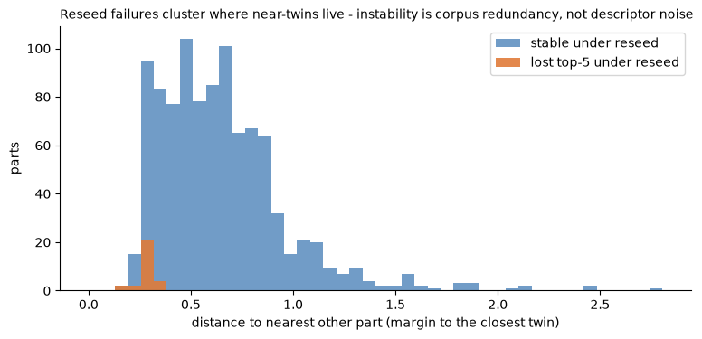

```python
# The near-duplicate story, quantified: do the 29 reseed-failures live where near-twins live?
fail = r_v0 > 5     # parts that lost top-5 under new darts (from the stability witness cell)
print(f"NN distance, failing parts : median {np.median(nn[fail]):.3f}  (n={int(fail.sum())})")
print(f"NN distance, stable parts  : median {np.median(nn[~fail]):.3f}  (n={int((~fail).sum())})")

fig, ax = plt.subplots(figsize=(9, 3.8))
bins = np.linspace(0, float(nn.max()), 45)
ax.hist(nn[~fail], bins=bins, color="#3572b0", alpha=0.7, label="stable under reseed")
ax.hist(nn[fail], bins=bins, color="#e07b39", alpha=0.9, label="lost top-5 under reseed")
ax.set_xlabel("distance to nearest other part (margin to the closest twin)")
ax.set_ylabel("parts")
ax.legend()
ax.set_title("Reseed failures cluster where near-twins live - instability is corpus redundancy, not descriptor noise",
             loc="left", fontsize=10)
ax.spines[["top", "right"]].set_visible(False)
plt.savefig("figures/margin_vs_stability.png", dpi=110, bbox_inches="tight")
plt.show()
```

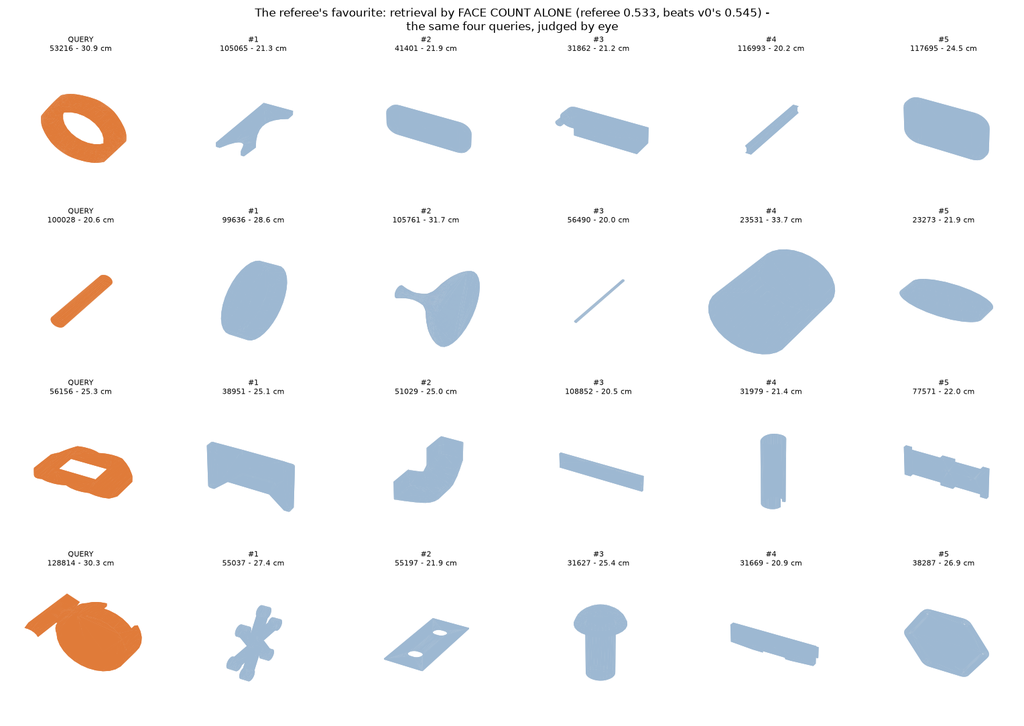

```python
# The check that settles it: what does the referee's favourite dumb retriever actually LOOK like?
# (Stability can't arbitrate - a deterministic retriever aces it by construction, the v1 tautology again.)
logfc = ds.scalars[:, 11]

def retrieve_by_facecount(stem, k=5):
    q = ds.index(stem)
    d = np.abs(logfc - logfc[q])
    d[q] = np.inf
    order = np.argsort(d)
    return [(str(ds.stems[i]), float(d[i]), ds.display[i]) for i in order[:k]]

queries = ["53216_2857e8ac_7", "100028_0c3a8f1c_1", "56156_c1e70978_8", "128814_4854736d_0"]
fig = plt.figure(figsize=(15.6, 11))
for r, qs in enumerate(queries):
    row = [(qs, 0.0, ds.display[ds.index(qs)])] + retrieve_by_facecount(qs)
    for c, (stem, dist, disp) in enumerate(row):
        ax = fig.add_subplot(4, 6, r * 6 + c + 1, projection="3d")
        render_part(ax, stem, "#e07b39" if c == 0 else "#9db8d2")
        head = "QUERY" if c == 0 else f"#{c}"
        ax.set_title(f"{head}\n{stem.split('_')[0]} - {disp[4]:.1f} cm", fontsize=8)
fig.suptitle("The referee's favourite: retrieval by FACE COUNT ALONE (referee 0.533, beats v0's 0.545) -\n"
             "the same four queries, judged by eye", fontsize=12)
plt.tight_layout()
plt.savefig("figures/retrieval_facecount_sanity.png", dpi=110, bbox_inches="tight")
plt.show()
```

**Test 3 verdict, revised after the ablation (supersedes the earlier verdict).**

The referee **can falsify (complexity-mismatched garbage would score badly), but it cannot certify shape relevance**, because the operation histogram records which buttons were pressed and how often. This is a quantity that tracks part complexity, while containing nothing about the geometry those operations produced. Two equally-complicated parts of completely different shapes look construction-similar to it. The face-count grid above shows exactly that.

**(1)** v0's win over random was substantially complexity-tracking, not construction-affinity. My earlier "systematic, modest, understated" reading over-credited the referee.

**(2)** v1's landslide is double-discounted: face-type family resemblance *and* complexity. My keep-both ruling survives but now rests almost entirely on the label-free visual witness.

**(3)** The Test-4 confidence gauge is calibrated against a partly-confounded ruler. A partial correlation controlling for face count is the named missing check.

**(4)** The direct measurement this suite still lacks is a small hand-labelled gold set (~30 queries, pre-registered "would I open this file as a starting point?", precision@5). The one instrument that measures the definition itself rather than approximating it.

*The chain that produced this section: build the referee, declare its biases, then construct the experiment that convicts it, and let the system's quality evidence stand on the witnesses that survive. This is the evaluation working as designed: the goal was never a flattering number, it was knowing which numbers to trust.*

### 7. Gold set (protocol registered before labelling)

The hardening pass left one instrument still missing: a *direct* measure of the defined relevance.

**Protocol**, fixed in `gold_set.py` and here **before labelling**:

- **30 queries**, 10 drawn from each third of the face-count range — simple, medium and complex parts (seed 0)
- per query the **blinded, shuffled union** of v0's and v1's top-5 (277 judgements total, system identity hidden)
- one candidate at a time beside the query (judged absolutely,never relative to pool-mates)
- the registered question: *"Would I open this file as a starting point for the query part?"* — y/n, **unsure counts as no** · labeller: me, in one sitting · scoring: **precision@5 per system** (of the five suggestions, the fraction I judged useful), broken down by the same three complexity groups. Labels are never edited after scores are seen.

Declared honestly: a single self-labelled rater is a bias risk, because the labeller is also the system's author. I mitigate it three ways, none of them a cure:

- blinding: which system produced a candidate is hidden while I judge it
- pre-registration: the question and the scoring rule were fixed before I saw a single result
- the conservative unsure-rule: anything I am unsure about scores as a no

That is standard practice at prototype scale, and the alternative, no direct measurement at all, was the weaker position.

**Same-rater repeat check (next morning, blind):** 3 sheets. (05/12/27, 28 judgements relabelled from scratch) with **28/28 agreement, zero flips**, including the unsure calls.

```python
!python gold_set.py score
```

```
precision@5 v0: 0.387  (per-tercile: 0.44 / 0.30 / 0.42)
precision@5 v1: 0.313  (per-tercile: 0.50 / 0.28 / 0.16)
paired mean difference (v0 - v1): +0.073 over 30 queries
```

```python
# Gold-set: paired comparison and the queries where nothing was useful
import json as _j
from scipy.stats import wilcoxon

_mapping = _j.load(open("gold/mapping.json"))
_labels = {}
for _line in open("gold/labels.tsv"):
    if _line.startswith("#") or _line.startswith("sheet") or not _line.strip():
        continue
    _parts = (_line.rstrip("\n").split("\t") + [""])[:5]
    _labels[(_parts[1], _parts[2])] = _parts[3].strip().lower()

_p5 = {"v0": [], "v1": []}
_zero = []
for _q, _m in _mapping.items():
    _rel = {c["stem"]: _labels[(_q, l)] == "y" for l, c in _m["candidates"].items()}
    _p5["v0"].append(np.mean([_rel[s] for s in _m["v0_top5"]]))
    _p5["v1"].append(np.mean([_rel[s] for s in _m["v1_top5"]]))
    if not any(_rel.values()):
        _zero.append(_q)
_a, _b = np.array(_p5["v0"]), np.array(_p5["v1"])
_d = _a - _b
print(f"v0 better on {int((_d > 0).sum())} queries, v1 better on {int((_d < 0).sum())}, tied {int((_d == 0).sum())}")
print(f"Wilcoxon signed-rank on paired P@5: p = {wilcoxon(_a, _b).pvalue:.3f}")
print(f"queries where NOTHING in either pool was useful: {len(_zero)}/30")
```

```
v0 better on 13 queries, v1 better on 9, tied 8
Wilcoxon signed-rank on paired P@5: p = 0.281
queries where NOTHING in either pool was useful: 4/30
```

**Gold-set verdict (the final word of the evaluation).** Direct human judgement puts **v0 at precision@5 = 0.387 and v1 at 0.313**.

Roughly two of five suggestions are genuinely useful starting points, measured against the registered question.

**The referee's v1 landslide does not survive human eyes: the direction reverses**, exactly as the bias convictions predicted.

The strongest validation of the evaluation chain itself (it took only n = 30 honest labels to break a p ≈ 10⁻⁷⁷ claim, because that claim measured the wrong thing).

**What only the labelling chair could find: reuse is asymmetric.** The collapse on the most complex third (v1: P@5 = 0.16) has a mechanism, discovered while judging: a retrieved part *simpler than the query* is not a starting point at all. Editing letters out of a plain block is more work than sketching the letters fresh.

Relevance = work saved, **and work saved can go negative.** Symmetric geometric similarity cannot express that asymmetry — a fundamental limitation of both v0 and v1, and the empirical anchor for the remaining-work / edit-distance framing of the problem.

Consistent with it: on 4 of 30 queries *nothing* in either pool was useful. ~13% of queries the honest product answer is "no good match in the archive," which is what the confidence gauge exists to say.

## 8. Conclusion

I built a CAD-to-CAD retrieval prototype: 1008 STEP parts fingerprinted with a 64-bin D2 shape distribution, exact nearest-neighbour search in memory, and a confidence gauge on every result. Direct human evaluation puts the shipped default at **precision@5 = 0.387**, roughly two useful starting points in every five suggestions, measured through 277 pre-registered, blinded judgements.

The evaluation taught me more than the retrieval did. My label-based referee turned out to reward complexity matching rather than shape relevance. A face-count-only retriever beat v0 on it while returning visual garbage, so I demoted the referee to a falsifier and rested the quality claim on label-free evidence plus the gold set. Hand-labelling exposed the deepest finding, that **reuse is asymmetric**. A retrieved part simpler than the query is no starting point at all, so "work saved" can go negative, and symmetric similarity cannot express that.

**Known limitations.**

- D2 is a global summary: it cannot tell a through-hole from a blind hole, four holes from four bosses, or a part from its mirror image.
- The v1 aspect ratios use an axis-aligned box, so their rotation-invariance is an accident of this database rather than a property of the descriptor.
- The database itself is simple single-body parts. A real archive of thin-walled, multi-body enclosures would stress a fingerprint that mostly sees the outer envelope.
- The gold set has one rater, and I am also the author. Blinding and pre-registration reduce that bias, they do not remove it.

**With another week.**

- The cheapest step first: D2's own siblings from the same paper, A3 (angles), D3 (triangle areas) and D4 (tetrahedron volumes), reuse my sampled points and histogram machinery unchanged. An afternoon of work. The gold labels would not transfer to a new retriever's top-5, so that step needs a fresh labelling round.
- Then a frozen b-rep-native encoder, UV-Net or BRepNet trained on this dataset's own structure, through the same four-test harness and gold set.
- Topology the b-rep already holds and I never read: hole counts and face-adjacency statistics.
- A directional complexity guard in the confidence layer, so a retrieval simpler than the query flags itself.
- Further out: construction-history edit distance as the honest relevance measure, and my 277 labels reused to calibrate a VLM judge so evaluation can scale past thirty queries.

### Appendix A · How far the b-rep is read, and why the line sits there

The brief pointed at the b-rep format and at BRepNet. This appendix states plainly how much of the b-rep this prototype reads, how much it leaves untouched, and why I drew the line where I did. The short version: the b-rep is the source of truth throughout, the exact scalars come from it, and the topology layer is deliberately unspent budget rather than an oversight.

**What a b-rep holds, and what I take from it.** A b-rep stores a solid as a hierarchy — solid → shells → faces → wires → edges → vertices — where each face carries an exact analytic surface plus trim curves, and the adjacency between them is explicit.

| Layer | What it contains | Read here |
| --- | --- | --- |
| Exact surfaces per face | type (plane, cylinder, cone, sphere, torus, Bézier, B-spline) **and its parameters**: a cylinder knows its radius and axis | Type only, as the 8 face-type fractions. Radii and axes: no |
| Exact integral quantities | volume, area, centre of mass, moments of inertia | Volume and area, via `brepgprop` — these feed sphericity and the display sizes |
| Per-face measurements | the exact area of each individual face | No. Face types are counted, not area-weighted |
| Topology graph | face adjacency, edge convexity, loops per face, genus | No |
| Derived features | holes, pockets, bosses, fillets, ribs — recoverable from the graph | No |
| Construction history | absent from STEP; the `.seg` labels are its shadow | Referee only, held out of every feature |

Two consequences worth stating rather than leaving to be discovered. The v1 scalars are b-rep-native and exact, which is *why* they cannot wobble under reseeding — the free pass §6 convicts. And the v0 ranking signal is **not** b-rep-native: it runs b-rep → tessellation at deflection 0.1 → 2048 surface samples → D2, a lossy projection of the file I went to some trouble to load exactly.

**Why the line sits there.** With zero relevance labels in this dataset, a topology descriptor would have been an unvalidated method: more expressive, and with no instrument capable of telling me whether it was better. I ordered the work the other way round — build the evaluation first, give it a deliberately weak and cheap v0 to grade, and find out what the harness can and cannot resolve before spending complexity on the descriptor. That ordering is what produced the findings I value most in this notebook: the referee conviction in §6, and the reuse asymmetry in §7. Neither would have surfaced from a better fingerprint.

**The unexploited layer is exactly where my failures live.** Every limitation named in §8 is a topology question that the b-rep answers and a sampled point cloud cannot:

- *Through-hole vs blind hole.* The inner loops on a face, and what the hole's cylindrical face is adjacent to: two planar faces for a through-hole, one plus a bottom face for a blind one.
- *Four holes vs four bosses.* Edge convexity. Pocket edges are concave, boss edges convex. Identical volume, identical D2, opposite topology.
- *The notched ring vs the smooth ring* (§3.2, the local-identity finding). v1 patches this indirectly through face-type mix; face adjacency would resolve it directly.
- *Reuse asymmetry* (§7). log₁₀(face count) is my only complexity handle. The topology graph gives a structural size, which is what a directional guard needs.

Diagnosing those failures and naming the representation that fixes each one is the reason the b-rep-native encoder sits at position 2–3 of the next-week list rather than at the top: the harness has to exist first, and §7 shows that a fresh retriever re-opens the labelling bill.

**One correction available at no methodological cost.** Face-type fractions are computed **by count**, so a housing with fifteen small fillet faces reads as fillet-dominated even where those faces carry 2% of the surface. `brepgprop` returns each face's exact area, so area-weighting the histogram is a few lines against the same kernel call I already make. I flag it here rather than folding it in silently: an unevaluated change is not an improvement, and it would need the same four-test harness and a fresh gold-set round before I would claim it helps.

### References & sources

**Methods**

- Osada, Funkhouser, Chazelle, Dobkin (2002). *Shape Distributions.* ACM Transactions on Graphics 21(4) — the D2 descriptor. https://doi.org/10.1145/571647.571648
- Wadell (1935). *Volume, Shape, and Roundness of Quartz Particles.* The Journal of Geology 43(3) — the sphericity measure ψ.
- Face-type mixes and bounding-box aspect ratios: standard practice in 3D shape retrieval, with no single canonical paper. Face types are input channels in the b-rep networks below — the field's neural networks eat the same features hand-crafted here.

**Dataset & b-rep learning context**

- Willis et al. (2021). *Fusion 360 Gallery: A Dataset and Environment for Programmatic CAD Construction.* ACM TOG (SIGGRAPH). https://github.com/AutodeskAILab/Fusion360GalleryDataset
- Lambourne et al. (2021). *BRepNet: A Topological Message Passing System for Solid Models.* CVPR — the model family behind the `.seg` labels. https://github.com/AutodeskAILab/BRepNet
- Jayaraman et al. (2021). *UV-Net: Learning from Boundary Representations.* CVPR.

**Considered for v2 (parked until evaluation exists)**

- Oquab et al. (2023). *DINOv2: Learning Robust Visual Features without Supervision* — pretrained vision embeddings on multi-view renders as a learned, label-free comparison.

**Tooling**

- OpenCASCADE (OCCT) b-rep kernel via `pythonocc-core` https://github.com/tpaviot/pythonocc-core · `trimesh` (area-weighted surface sampling) https://github.com/mikedh/trimesh · NumPy / Matplotlib / Jupyter.